# Prediction of Barbell Lifts from Accelerometer Data

tiger13

Tuesday, April 19, 2016

## Executive Summary

A boosted tree-based learning method can predict the type of barbell curl performed using data collected from belt, arm, forearm, and dumbbell accelerometer measurements. The data are from this source: http://groupware.les.inf.puc-rio.br/har

## Exploratory Data Analysis and Data Set Creation

```r
library(caret)
dataIn = read.csv('C:/Users/Ron/Documents/DataScience/datasets/PracticalMachineLearning/pml-training.csv')
```

The data set is large enough to have a training set, test set, and validation set. Make them 60%, 20%, and 20%, respectively, of the input data set.

```r
set.seed(2016)
inTrain = createDataPartition(y=dataIn$classe, p=0.6, list=FALSE)
trainingFull = dataIn[inTrain,]
notTraining = dataIn[-inTrain,]
inTest = createDataPartition(y=notTraining$classe, p=0.5, list=FALSE)
testingFull = notTraining[inTest,]
validationFull = notTraining[-inTest,]
```

First, let’s perform some exploratory data analysis. As seen in the following plots, some of the variables are time series and others are summary statistics for the series. As a result, the columns with summary statistics have mostly NA entries. We will remove the columns with the summary statistics.

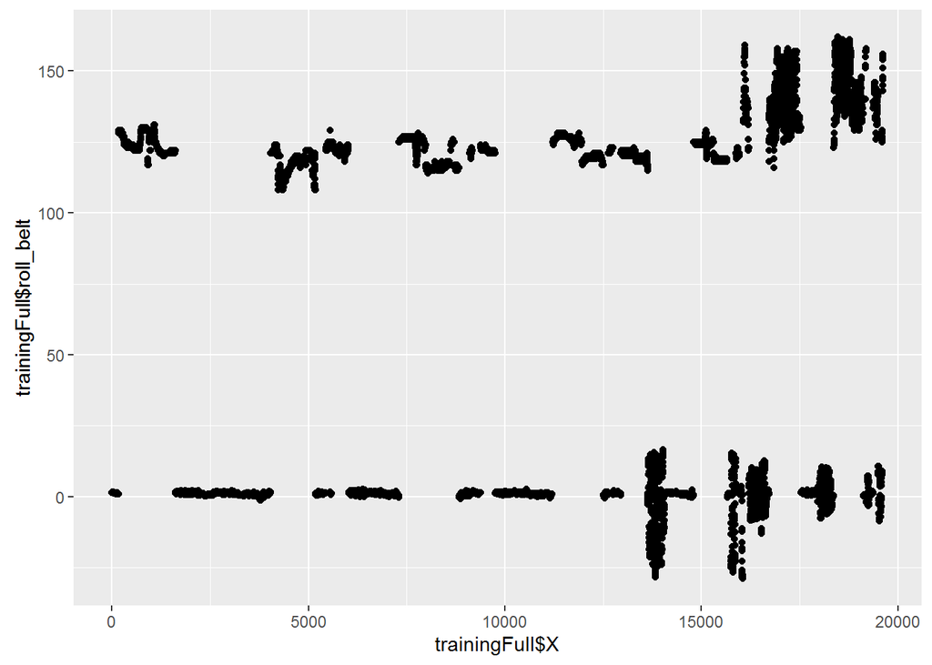

```r
qplot(trainingFull$X, trainingFull$roll_belt)
```

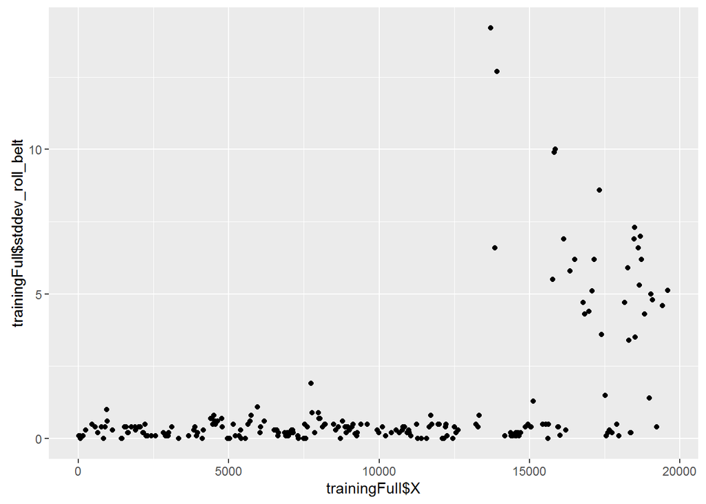

```r
qplot(trainingFull$X, trainingFull$stddev_roll_belt)
```

```r
colsWithNA = apply(trainingFull, 2, anyNA)
validNamesTraining = names(trainingFull)[!colsWithNA]
```

Read in the final test set. We must NOT train on this set,but it will be important to know which variables appear in this data. Our starting set of variables for further analysis will be the minimal variable set that appears in both the training and test data, in other words, the intersection of the non-NA variables in the two sets.

```r
finalTestDataIn = read.csv('C:/Users/Ron/Documents/DataScience/datasets/PracticalMachineLearning/pml-testing.csv')

testColsWithNA = apply(finalTestDataIn, 2, anyNA)
validNamesTest = names(finalTestDataIn)[!testColsWithNA]

validNames = intersect(validNamesTraining, validNamesTest)
```

The first seven variables are time stamps and other information we will not use in training. Remove those names from the list of columns with valid data.

```r
validNames = validNames[8:59]
```

Now find the data which will be used in training.

```r
training = trainingFull[, validNames]
training$classe = trainingFull$classe
```

So that knitr can produce the output document in a reasonable amount of time, we will need a smaller training data set.In real-world use, the full training set would be used.

```r
trainingSmall = training[seq(from=1, to=length(training[,1]), by = 5),]
```

### Standardization of Variables

We do not explicity standardize the variables because when using tree classifiers, as we do below, the results will be the same with and without standardization.

## Training and Model Selection

We now fit models to the training data and select the best, making sure that the results are cross-validated to prevent overfitting. The analogue to cross-validation for tree-based methods is resampling. We set the number of resamples to 10.

```r
modFit = train(classe~., method="gbm", data=trainingSmall, trControl=trainControl(number=10), verbose=FALSE)
pred = predict(modFit, training)
confusionMatrix(pred, training$classe)
```

```
## Confusion Matrix and Statistics
##
##           Reference
## Prediction    A    B    C    D    E
##          A 3284   92    4    2    7
##          B   26 2101   62    4   29
##          C   16   67 1964   68   22
##          D   18    6   18 1840   28
##          E    4   13    6   16 2079
##
## Overall Statistics
##
##                Accuracy : 0.9569
##                  95% CI : (0.953, 0.9605)
##     No Information Rate : 0.2843
##     P-Value [Acc > NIR] : < 2.2e-16
##
##                   Kappa : 0.9454
##  Mcnemar's Test P-Value : < 2.2e-16
##
## Statistics by Class:
##
##                      Class: A Class: B Class: C Class: D Class: E
## Sensitivity            0.9809   0.9219   0.9562   0.9534   0.9603
## Specificity            0.9875   0.9873   0.9822   0.9929   0.9959
## Pos Pred Value         0.9690   0.9455   0.9190   0.9634   0.9816
## Neg Pred Value         0.9924   0.9814   0.9907   0.9909   0.9911
## Prevalence             0.2843   0.1935   0.1744   0.1639   0.1838
## Detection Rate         0.2789   0.1784   0.1668   0.1562   0.1765
## Detection Prevalence   0.2878   0.1887   0.1815   0.1622   0.1799
## Balanced Accuracy      0.9842   0.9546   0.9692   0.9731   0.9781
```

### Analysis of Model Fit

Now prepare the test data set, predict the values, and calculate the accuracy.

```r
testing = testingFull[, validNames]
testing$classe = testingFull$classe

predTest = predict(modFit, testing)
confusionMatrix(predTest, testing$classe)
```

```
## Confusion Matrix and Statistics
##
##           Reference
## Prediction    A    B    C    D    E
##          A 1104   52    4    0    6
##          B    4  680   37    1   13
##          C    3   24  633   33   15
##          D    5    1    9  598   11
##          E    0    2    1   11  676
##
## Overall Statistics
##
##                Accuracy : 0.9409
##                  95% CI : (0.933, 0.948)
##     No Information Rate : 0.2845
##     P-Value [Acc > NIR] : < 2.2e-16
##
##                   Kappa : 0.9251
##  Mcnemar's Test P-Value : 8.124e-15
##
## Statistics by Class:
##
##                      Class: A Class: B Class: C Class: D Class: E
## Sensitivity            0.9892   0.8959   0.9254   0.9300   0.9376
## Specificity            0.9779   0.9826   0.9768   0.9921   0.9956
## Pos Pred Value         0.9468   0.9252   0.8941   0.9583   0.9797
## Neg Pred Value         0.9956   0.9752   0.9841   0.9864   0.9861
## Prevalence             0.2845   0.1935   0.1744   0.1639   0.1838
## Detection Rate         0.2814   0.1733   0.1614   0.1524   0.1723
## Detection Prevalence   0.2972   0.1874   0.1805   0.1591   0.1759
## Balanced Accuracy      0.9836   0.9393   0.9511   0.9610   0.9666
```

```r
combinedTraining = rbind(training, testing)

trainingSmall = combinedTraining[seq(from=1, to=length(combinedTraining[,1]), by = 5),]

modFit = train(classe~., method="gbm", data=trainingSmall, trControl=trainControl(number=10), verbose=FALSE)

validation = validationFull[, validNames]
validation$classe = validationFull$classe

predValidation = predict(modFit, validation)
confusionMatrix(predValidation, validation$classe)
```

```
## Confusion Matrix and Statistics
##
##           Reference
## Prediction    A    B    C    D    E
##          A 1093   53    2    3    4
##          B   10  678   29    1   15
##          C    3   26  643   30    6
##          D    6    0    7  602   17
##          E    4    2    3    7  679
##
## Overall Statistics
##
##                Accuracy : 0.9419
##                  95% CI : (0.9341, 0.949)
##     No Information Rate : 0.2845
##     P-Value [Acc > NIR] : < 2.2e-16
##
##                   Kappa : 0.9264
##  Mcnemar's Test P-Value : 2.225e-09
##
## Statistics by Class:
##
##                      Class: A Class: B Class: C Class: D Class: E
## Sensitivity            0.9794   0.8933   0.9401   0.9362   0.9417
## Specificity            0.9779   0.9826   0.9799   0.9909   0.9950
## Pos Pred Value         0.9463   0.9250   0.9082   0.9525   0.9770
## Neg Pred Value         0.9917   0.9746   0.9872   0.9875   0.9870
## Prevalence             0.2845   0.1935   0.1744   0.1639   0.1838
## Detection Rate         0.2786   0.1728   0.1639   0.1535   0.1731
## Detection Prevalence   0.2944   0.1868   0.1805   0.1611   0.1772
## Balanced Accuracy      0.9787   0.9379   0.9600   0.9635   0.9684
```

### Conclusion

A boosted tree-based learning method can predict the type of barbell curl performed using data collected from belt, arm, forearm, and dumbbell accelerometer measurements.